# Experimental Design for AI Evaluation

Session 5

2026-09-29

## This week’s links in the total error chart

Last week: valid scores. Today: which units and which comparisons.

```
%%{init: {"theme": "base", "flowchart": {"nodeSpacing": 60, "rankSpacing": 26, "padding": 6}, "themeVariables": {
  "primaryColor": "#ffffff", "primaryBorderColor": "#3b5998", "primaryTextColor": "#2d3748",
  "lineColor": "#6c757d", "edgeLabelBackground": "#ffffff",
  "fontFamily": "Domitian, Palatino, serif", "fontSize": "22px"}}}%%
flowchart TD
    A["PURPOSE"] --> B["INQUIRY"]
    B --> S["SAMPLE"]
    S --> C["EVALUATION DESIGN"]
    C --> D["OBSERVED EVIDENCE"]
    D --> E["ANSWER / CLAIM"]
    e1["<b style='color:#ba0020'>construct error</b> <i style='font-size:17px;color:#8a94a0'>(lecture 02)</i><br/><span style='color:#2d3748'>the question is not the thing that matters</span>"] -.-> B
    e2["<b style='color:#ba0020'>coverage &amp; sampling error</b> <i style='font-size:17px;color:#8a94a0'>(today)</i><br/>these users, tasks, and prompts stand in badly for the ones you care about"] -.-> S
    e3["<b style='color:#ba0020'>implementation &amp; assignment error</b> <i style='font-size:17px;color:#8a94a0'>(today: assignment)</i><br/>the study does not create the comparison it says it does"] -.-> C
    e4["<b style='color:#ba0020'>measurement, scoring &amp; contamination error</b> <i style='font-size:17px;color:#8a94a0'>(lecture 04)</i><br/>the score is a noisy or invalid stand-in for performance"] -.-> D
    e5["<b style='color:#ba0020'>analysis &amp; inference error</b> <i style='font-size:17px;color:#8a94a0'>(later)</i><br/>the answer overstates the evidence, or travels farther than the design permits"] -.-> E
    e0[" "] ~~~ e1
    e1 ~~~ e2
    e2 ~~~ e3
    e3 ~~~ e4
    e4 ~~~ e5
    classDef err fill:#ffffff,stroke:#ba0020,stroke-width:1px,stroke-dasharray:5 4,color:#6c757d;
    classDef focus fill:#fff3f4,stroke:#ba0020,stroke-width:4px,color:#2d3748;
    classDef spacer fill:none,stroke:none;
    class e1,e4,e5 err
    class e2,e3 focus
    class e0 spacer
    style S stroke:#ba0020,stroke-width:4px
    style C stroke:#ba0020,stroke-width:4px
    linkStyle 6,7 stroke:#ba0020,stroke-width:4px
    linkStyle 5,8,9 stroke:#ba0020,stroke-width:1.5px
```

# Simulation and power

## Test retrieval’s effect on learning

- **Task:** students practice course problems with a chatbot.
- **Outcome:** points on a later **unaided quiz of new problems**, using last week’s rubric.
- **Treatment:** give the chatbot access to course notes during practice.
- **Design:** 200 students; randomly assign 100 to retrieval on, 100 to off.
- **Hold fixed:** practice problems, model, generic instruction, and quiz.

Can this study reliably detect a 3-point improvement in unaided quiz scores?

## Simulate the main features of your outcome

- **Outcome:** the unaided quiz score, on a 0–100 scale.
- **Student variation:** students differ in expected quiz performance.
- **Measurement noise:** question selection and scoring add variation.
- **Treatment effect:** retrieval during practice may shift expected performance.
- The tuning demo models individual ratings of model answers at a specified annotator reliability.

## Simulate learning and measurement separately

$$\text{Quiz score}=\text{expected performance}+\text{treatment effect}+\text{noise}.$$

- Retrieval shifts **expected unaided performance** by 3 points.

```r
N <- 200
model <- declare_model(
  N = N, T0 = rnorm(N, mean = 50, sd = 8),
  error = rnorm(N, sd = 6),
  potential_outcomes(Y ~ T0 + 3 * Z + error)
)
inquiry <- declare_inquiry(
  ATE = mean(Y_Z_1 - Y_Z_0)
)
```

More measurement noise makes the same effect harder to detect.

## Declare how the study produces an answer

```r
assignment <- declare_assignment(
  Z = complete_ra(N, m = N / 2)
)
measurement <- declare_measurement(
  Y = reveal_outcomes(Y ~ Z)
)
estimator <- declare_estimator(
  Y ~ Z, .method = lm_robust, inquiry = "ATE"
)
design <- model + inquiry + assignment +
  measurement + estimator
```

Complete randomization fixes 100 people per Bundle. `lm_robust` estimates their mean difference with a robust standard error.

## One simulated study produces one answer

```r
set.seed(2)
one_study <- draw_data(design)
one_answer <- estimator(one_study)
```

| Estimate | SE | Lower 95% | Upper 95% |
| --- | --- | --- | --- |
| 5.402 | 1.464 | 2.516 | 8.288 |

- The true effect in our model is 3 points.
  - Random assignment and the sample determine the answer from this particular study.
- Repeating the full study shows how much that answer varies.

## Repetition reveals uncertainty

```r
diagnosis <- diagnose_design(design, sims = 500)
get_diagnosands(diagnosis)
```

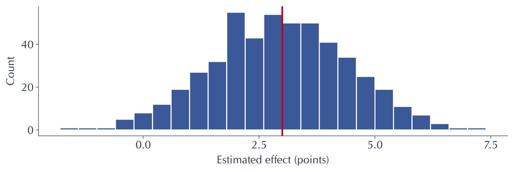

The red line is the true effect, 3 points. **Bias** is displacement of the average estimate; **precision** is the spread across studies.

## Larger samples help detect smaller effects

**Power** is the fraction rejecting a specified false null. Here: two-sided tests at 5%.

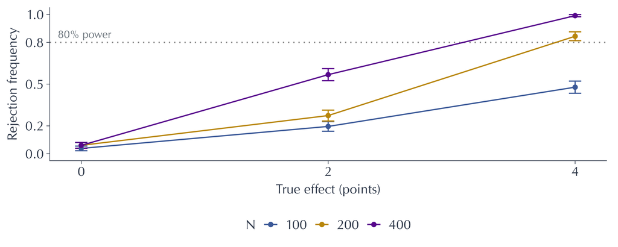

- At effect zero, rejection rate is Type I error.
- Smallest effect size with power $\geq$ 80% is the “minimal detectable effect” (MDE)

## Summary: `DeclareDesign` for power analysis

- **Represent your data:**
  - score variation, differences across people or items, and repeated measurements.
- **Simulate your design and analysis:**
  - sample sizes, treatment assignment, comparisons, and tests.
- **Vary plausible effects and assumptions:**
  - identify which effects you can reliably detect.

Your pre-analysis plan (PAP) must discuss power.

- Given your design and measures, what effect sizes do you expect to detect?
- Report power or an MDE for your main contrast, in meaningful units, with the assumptions behind it.

Worked code and tuning steps: DeclareDesign walkthrough · Runnable QMD.

# Factorial experiments

## Vary components of the Bundle

Every condition, including the control, specifies settings in the Bundle.

| Bundle component | Possible variation |
| --- | --- |
| Model weights | Smaller vs. larger model |
| Decoding | Lower vs. higher temperature |
| Instruction (prompt) | Generic assistance vs. hint-first tutoring |
| Retrieval (harness) | Course-note access off vs. on |
| Interface | Chat window vs. hints beside the problem |
| Workflow | Help available immediately vs. after an attempt |

We will cross instruction and retrieval, holding the other components fixed, to separate their effects and interaction.

## Cross two components to create four Bundles

During practice, vary course-note retrieval $R$ and hint-first instruction $H$.

|  | Generic instruction: $H=0$ | Hint-first instruction: $H=1$ |
| --- | --- | --- |
| Retrieval off: $R=0$ | $B_{00}$ | $B_{01}$ |
| Retrieval on: $R=1$ | $B_{10}$ | $B_{11}$ |

- **Hold fixed:** the unaided quiz and all other Bundle components.
- **Reference $B_{00}$:** a functioning chatbot with generic instruction and retrieval off.
- **Expand the comparison:**
  - Before: retrieval alone, $B_{10}$ vs. $B_{00}$.
  - Now: cross retrieval with instruction.
  - Estimate each component’s effect and their interaction.

## A linear model makes the contrasts explicit

$$Y_i(r,h)=\mu+a_i+\beta_Rr+\beta_Hh+\beta_{RH}rh+\epsilon_i.$$

$a_i$: differences in true quiz performance. $\epsilon_i$: quiz and scoring noise.

Set $\mu=50$, $\beta_R=3$, $\beta_H=1$, $\beta_{RH}=4$.

| Expected quiz score | Generic | Hint-first |
| --- | --- | --- |
| Retrieval off | 50 | 51 |
| Retrieval on | 53 | 58 |

Scores and effects are in points. Baseline SD: 10 points; Gaussian approximation.

## A component effect depends on the other components

| Contrast | Formula | Points |
| --- | --- | --- |
| Retrieval with generic instruction | $\beta_R$ | 3 |
| Retrieval with hint-first instruction | $\beta_R+\beta_{RH}$ | 7 |
| Both on vs. both off | $\beta_R+\beta_H+\beta_{RH}$ | 8 |
| Interaction: change in retrieval effect | $\beta_{RH}$ | 4 |

- The interaction says that retrieval helps more under hint-first instruction here.
- Larger effects mean more power (all else equal)!

## The AMCE averages over specified Bundle settings

- **Average marginal component effect (AMCE):** average a component’s effect over the other components.
  - $p$: probability of hint-first instruction in the target distribution.

$$\operatorname{AMCE}_R=\beta_R+p\beta_{RH}.$$

- **Choose the weights:** $p=1/2$ gives **5 points**; $p=1/4$ gives **4 points**.
- **Why average?** Pool observations across settings of the other components.
  - Can improve power relative to comparing just two cells.
  - Especially useful with many components: no need to estimate every cell mean.
- **With independent randomization:** many full cells can be empty in the sample.
  - Both component levels must still be possible at the settings we average over.

Hainmueller, Hopkins & Yamamoto (2014), [Causal Inference in Conjoint Analysis](https://doi.org/10.1093/pan/mpt024).

## Expand the declaration to four Bundles

Use the same model–inquiry–data–answer structure.

```r
assignment <- declare_assignment(
  cell = complete_ra(N,
    conditions = c("B00", "B10", "B01", "B11"),
    m_each = rep(N / 4, 4))
)
inquiry <- declare_inquiry(
  AMCE_R = mean((Y_B10 - Y_B00 +
                 Y_B11 - Y_B01) / 2),
  interaction = mean(Y_B11 - Y_B01 - Y_B10 + Y_B00)
)
```

## Power differs across contrasts in the same experiment

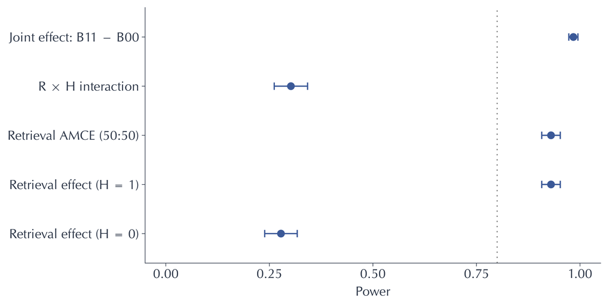

$N=50$ per Bundle. Power depends on each contrast’s effect size **and** uncertainty.

# Within versus between designs

## Who receives each Bundle?

- **A:** retrieval off. **B:** retrieval on.
  - Hold instruction and other components fixed.
- **Between participants:** each person receives one Bundle.
  - Randomize people to **A** or **B**.
  - Compare average scores across the two groups.
- **Within participants:** each person receives both Bundles.
  - Randomize order: **A → B** or **B → A**.
  - Score comparable tasks under each; compare within-person differences.
- **Model evaluations:** pair A and B on the same item, in separate fresh runs.

## Within designs remove shared variation

- **Compare two Bundles:** $c\in\{0,1\}$.

$$Y_{ic}=\mu+\tau c+a_i+\epsilon_{ic}.$$

- **Difference within a person or item:**

$$D_i=Y_{i1}-Y_{i0}=\tau+\epsilon_{i1}-\epsilon_{i0}.$$

- Shared ability or difficulty ($a_i$) cancels.
- **Assumption:** no carryover between Bundle exposures.
- **People:** use comparable tasks.
  - Randomize order and task-to-Bundle allocation.
- **Models:** use the same item and scoring rule.
  - Reset context and isolate tool state.

## Positive covariance makes pairing useful

- **In the model:** $a_i$ and the $\epsilon_{ic}$ terms are independent.
  - Shared variation: $\operatorname{Var}(a_i)=\sigma_a^2$.
  - Residual variation: $\operatorname{Var}(\epsilon_{ic})=\sigma_\epsilon^2$.

$$V_{\text{within}}=\frac{2\sigma_\epsilon^2}{n},\qquad
V_{\text{between}}=\frac{2(\sigma_a^2+\sigma_\epsilon^2)}{n}.$$

- **Same score count:** $2n$.
  - Within: $n$ pairs. Between: $n$ separate units per arm.
- **Correlation is the shared fraction:** $\rho=\sigma_a^2/(\sigma_a^2+\sigma_\epsilon^2)$.
  - 80% shared variation: pairing leaves **one fifth** of the variance.
  - No shared variation ($\sigma_a^2=0$): no gain.
- Recruitment costs and participant burden may still differ.

## Declare paired scores and estimate their differences

```r
model <- declare_model(
  N = 100, a = rnorm(N, sd = 10 * sqrt(rho)),
  Y_A = 50 + a + rnorm(N, sd = 10 * sqrt(1 - rho)),
  Y_B = 53 + a + rnorm(N, sd = 10 * sqrt(1 - rho))
)
inquiry <- declare_inquiry(ATE = 3)
measurement <- declare_measurement(D = Y_B - Y_A)
```

- **Estimate:** `mean(D)`.
  - Standard error: `sd(D) / sqrt(N)`.
  - Use a t interval and test.
- **Target:** population mean difference across units and runs.

## Pairing helps when the shared component is large

```r
diagnose_design(make_paired(rho = .8), sims = 500)
```

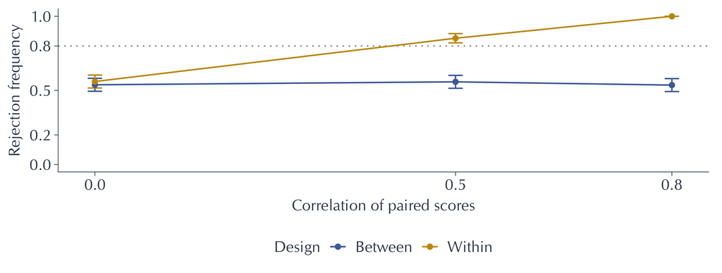

- **Fixed:** 200 outcomes; $\tau=3$; marginal SD = 10 points.
- **Vary `rho`:** how does comparability change power?

## Carryover breaks the two-Bundle SUTVA assumption

- **SUTVA:** no interference or hidden treatment versions.
  - A after B can differ from A with no prior exposure.
  - The current Bundle alone no longer defines the outcome.

$$Y_{it}=\mu+a_i+\tau Z_{it}+\delta\,1(t=2)+\lambda Z_{i,t-1}.$$

- $\tau$: fresh-exposure effect; $\delta$: common period effect.
- $\lambda$: **carryover** from previous treatment.
  - People retain learning; model runs retain context or tool state.
- **Consequence:** the paired contrast can miss the fresh-exposure effect.

## Counterbalancing leaves carryover bias

- **A:** comparison Bundle. **B:** treatment Bundle.

| Randomized sequence | Expected B − A |
| --- | --- |
| A then B | $\tau+\delta$ |
| B then A | $\tau-\delta-\lambda$ |

- **Balance the sequences:** equally many people in each.

$$E[\hat\tau]=\tau-\lambda/2.$$

- Common period effect ($\delta$) cancels.
- Carryover leaves bias: $-\lambda/2$.
  - Randomizing order does **not** remove it.

## Within designs can be precise but biased

| Design | Bias | SD of estimates | 95% coverage |
| --- | --- | --- | --- |
| Crossover: carryover 0 | -0.077 | 1.020 | 0.938 |
| Crossover: carryover 3 points | -1.605 | 0.978 | 0.640 |
| Crossover: carryover 6 points | -2.999 | 0.991 | 0.156 |
| Parallel groups | 0.005 | 1.385 | 0.958 |

- **Coverage:** fraction of 95% intervals containing the target.
- **Target:** fresh-exposure effect, $\tau=3$; 200 outcomes.
- **People:** 100 in crossover; 200 in parallel groups.
- **Tradeoff:** lower variance can come with bias and poor coverage.

# Blocking

## Blocking creates comparisons among similar people

- **Form blocks before assignment:** group people with similar pretest scores.
  - Sort 80 people by score; split into 4 groups of 20.
  - $b(i)$: person’s block; $\gamma_{b(i)}$: shared baseline component.
  - The best thing to block on is the *prognostic score*, a prediction of $Y(0)$.

$$Y_i(0)=\mu+\gamma_{b(i)}+\epsilon_i,\qquad
Y_i(1)=Y_i(0)+\tau.$$

```r
assignment <- declare_assignment(
  Z = block_ra(blocks = block)
)
```

- **Randomize within each block:** 10 people per Bundle.
- **Estimate:** average the block contrasts, weighted by block size.

Gerber & Green (2012), §§3.6.1, 4.4.

## A special case gives a predictiveness threshold

- **Assume:** fixed population and constant effects.
  - $J$ equal-sized blocks; same treatment fraction in every block.

$$\frac{V_{\text{blocked}}}{V_{\text{complete}}}
=(1-R_B^2)\frac{N-1}{N-J}.$$

- **Blocking improves precision when:**

$$R_B^2>\frac{J-1}{N-1}.$$

- $R_B^2$: share of $Y(0)$ variation explained by block indicators.
- $N=80$, $J=4$: threshold = **3.8%**.

Gerber & Green (2012), §3.6.1: variance comparison with complete randomization, specialized to equal blocks and constant effects.

## Prognostic blocks reduce assignment variability

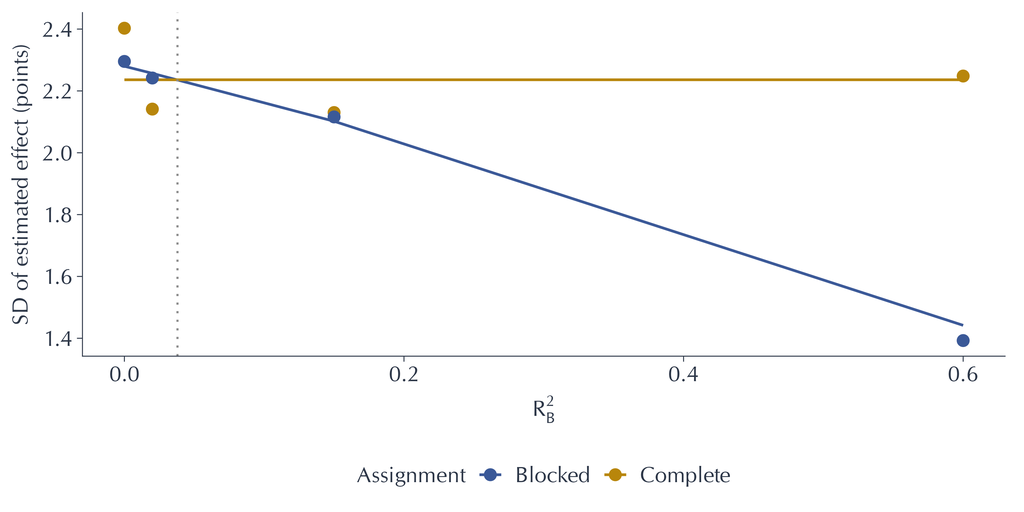

- **Lines:** analytic SD. **Points:** simulated SD.
- **Simulation:** fixed population; repeated assignment.
- **Choose blocks:** use pretreatment information or pilot evidence.

# Sampling and the evaluation budget

## Which population should the comparison inform?

- **So far:** how to compare Bundles. **Now:** which users and questions to study.
- **Human study target:** students who could use the tutor.

[figure not shown]

- Sampling and participation: who enters the study.
- Random assignment: which Bundle they receive.
  - Randomization alone does not make participants representative.

Adapted from [Dahabreh et al. (2021), *Study designs for extending causal inferences from a randomized trial to a target population*.](https://doi.org/10.1093/aje/kwaa270)

## Questions and prompt phrasings are populations too

- **Mizrahi et al.:** changing instruction wording can change model rankings.
  - One wording gives a narrow view of performance.

| Sample dimension | Example target population |
| --- | --- |
| Questions | New questions covering the course’s topics and difficulty range |
| Prompt phrasings | Ways intended users might ask those questions |

- **Design choice:** specify what is fixed and what is sampled.
  - If instruction is a treatment factor, sample phrasings within each level.
  - Paraphrases from a generator need not match real users’ wording.
- **Claim:** an average over a stated population of possible questions and users.
  - More seeds on the same questions cannot fix missing task types.

[Mizrahi et al. (2024), *State of What Art?*](https://aclanthology.org/2024.tacl-1.52/) Next week: [Miller (2024), *Adding Error Bars to Evals*.](https://arxiv.org/abs/2411.00640)

## Paired comparisons still vary across questions

- **Model evaluation:** retrieval on vs. off, on the same sampled questions.
  - Fresh runs; score the model’s answers. Hold instruction fixed.
- **Target:** average retrieval effect across possible course questions.

$$D_{ir}=Y_{ir}(B)-Y_{ir}(A)=\tau+u_i+e_{ir}.$$

- $u_i$: retrieval helps some questions more than others.
- $e_{ir}$: run-to-run noise in the paired score difference.

$$V(\bar D)=\frac{\sigma_u^2}{I}+\frac{\sigma_e^2}{IR}.$$

- **$I$ questions:** more questions reduce both terms.
- **$R$ runs per Bundle per question:** repeats reduce only run noise.
  - Average repeats within questions; estimate uncertainty across questions.

## Spend the same budget on questions or repeated runs

- **Fix:** two Bundles, a 3-point effect, and a budget of **1,200 cost units**.
- **Choose:** $R=1,2,5,$ or $10$ runs per Bundle per question.
  - Use the remaining budget to maximize the number of questions $I$.

$$I=\left\lfloor\frac{1200}{c_{\text{question}}+2R}\right\rfloor.$$

- **Run cost:** 1, including scoring. **Question preparation:** 0 or 10.
  - At cost 10: **100 questions × 1 run** or **40 questions × 10 runs**.
- **Two possible sources of variation:**
  - Mostly question differences: $(\sigma_u,\sigma_e)=(8,6)$.
  - Mostly run noise: $(\sigma_u,\sigma_e)=(2,10)$.
- **For each allocation:** simulate 500 studies.
  - Power = fraction detecting the effect with a two-sided 5% test.

## How much power can the same budget buy?

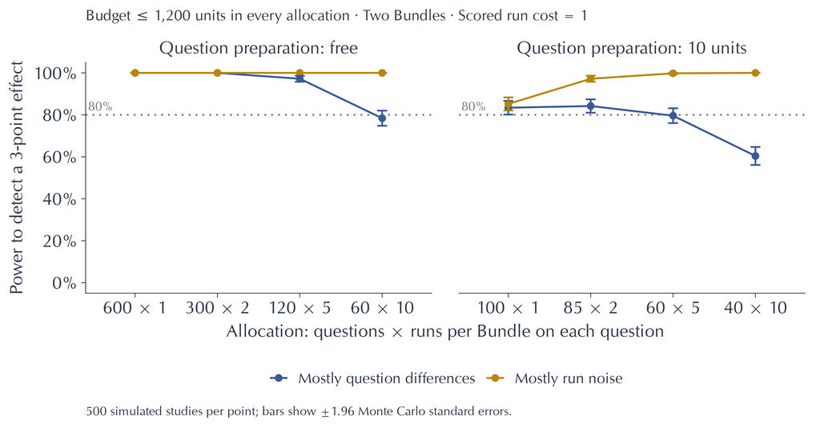

- **Costly questions + noisy runs:** repeats can help; fewer questions may suffice.
- **Effects vary across questions:** too many repeats sacrifice power.

# Workshop preparation

## Bring your design decisions to next week’s workshop

- **Build on your Bundle and comparison:** lock in the estimand between them.
- **Specify sampling:** who or what, from which population, and how.
- **Bring an initial power analysis.**
  - Use plausible measurement and design assumptions.
  - Start from this week’s worked example.
  - Vary assumptions and design choices; see what you could detect.
- **Together:** discuss these decisions and what else to consider.
- **Power analysis is approximate:** its answers depend on your assumptions.
  - Use it to think quantitatively about the consequences of design decisions.

Think of it like a structure for clearer thinking.